# Biological Predictors for Diabetes Mellitus Type II

## 0.1 Preliminaries

```r
library(skimr);library(dplyr);library(rms);library(pander);library(simputation);library(leaps);library(tidyverse) # function %>% in this package
```

# 1 Task 1: Data Source

These data are courtesy of Dr. John Schorling, Department of Medicine, University of Virginia School of Medicine. It was published in Willem JP Saunder JT Hunt DE Schorling JB “Prevalence of Coronary Heart Disease Risk Factors among Rural Blacks: a Community-based Study.” *Southern Medical Journal* (1997) 90:814-820. The article can be found [here](https://www.ncbi.nlm.nih.gov/pubmed/9258308). The data can be retrieved from [here](http://biostat.mc.vanderbilt.edu/wiki/Main/DataSets?CGISESSID=10713f6d891653ddcbb7ddbdd9cffb79)

The data in the `diabetes.csv` file consist of 403 of 1046 subjects that were interviewed to better understand the correlations between diabetes, obesity and other cardiovascular risk factors in central Virginia for African American. Only 403 subjects that were actually screened for diabetes were included in the data file and the dataset now has 403 subjects and 19 variables. Among others, Dr. John Schorling and his collegues were interested in the waist/hip ratio as a predictor in diabetes and heart disease.

# 2 Task 2: Load and Tidy the Data

```r
diabetes.raw <- read.csv("~/Case Grad/2018.Spring/PQHS 432/Project 1/data/diabetes.csv", sep = ",") %>% tbl_df

diabetes <- diabetes.raw %>%
  rename(subject = id) %>%
  mutate(subject = 1:nrow(diabetes.raw),
         diabetic = as.factor(ifelse(glyhb > 7.0, 1, 0)),
         bmi = weight/(height^2) * 703,
         bmi.cat = case_when(bmi < 18.5 ~ 'Underweight',
                             bmi < 25.0 & bmi >= 18.5 ~ 'Normal',
                             bmi < 30.0 & bmi >= 25.0 ~ 'Overweight',
                             bmi >= 30.0 ~ 'Obese'),
         bmi.cat = fct_relevel(bmi.cat, 'Underweight', 'Normal', 'Overweight',
                               'Obese'))%>%
  select(subject, chol, hdl, ratio, glyhb, age, gender, height, weight, bp.1s, bp.1d,
         waist, hip, diabetic, bmi, bmi.cat)

map_df(diabetes, function(x) sum(is.na(x)))
```

```
# A tibble: 1 x 16
  subject  chol   hdl ratio glyhb   age gender height weight bp.1s bp.1d
    <int> <int> <int> <int> <int> <int>  <int>  <int>  <int> <int> <int>
1       0     1     1     1    13     0      0      5      1     5     5
# ... with 5 more variables: waist <int>, hip <int>, diabetic <int>,
#   bmi <int>, bmi.cat <int>
```

```r
rm(diabetes.raw)
```

A new column was created which determines if the subject is diabetic or not depending on their glycosolated hemoglobin level. `glyhb` > 7.0 is usually diagnosed as positive for diabetes. Also, `bmi` and `bmi.cat` columns were made to determine body mass index of each subject and observe which categories they fall into. The BMI categories were made from the standard weight status categories associated with BMI ranges for adults presented by [Centers for Disease Control and Prevention](https://www.cdc.gov/healthyweight/assessing/bmi/adult_bmi/index.html). Any data that are of not my interest were taken out. These include `stab.glu`, `location`, `frame`, and `time.ppn`.

I conclude from the missing data output that:

- `hdl` is missing one subject
- `ratio` is missing one subject
- `glyhb` is missing 13 subject
- `height` is missing five subject
- `weight` is missing one subject
- `bp.1s` is missing five subject
- `bp.1d` is missing five subject
- `waist` is missing two subject
- `hip` is missing two subject
- `diabetic` is missing 13 subject
- `bmi` is missing 6 subject
- `bmi.cat` is missing 6 subject

# 3 Task 3: Listing of My Tibble

```r
diabetes
```

```
# A tibble: 403 x 16
   subject  chol   hdl ratio glyhb   age gender height weight bp.1s bp.1d
     <int> <int> <int> <dbl> <dbl> <int> <fct>   <int>  <int> <int> <int>
 1       1   203    56  3.60  4.31    46 female     62    121   118    59
 2       2   165    24  6.90  4.44    29 female     64    218   112    68
 3       3   228    37  6.20  4.64    58 female     61    256   190    92
 4       4    78    12  6.50  4.63    67 male       67    119   110    50
 5       5   249    28  8.90  7.72    64 male       68    183   138    80
 6       6   248    69  3.60  4.81    34 male       71    190   132    86
 7       7   195    41  4.80  4.84    30 male       69    191   161   112
 8       8   227    44  5.20  3.94    37 male       59    170    NA    NA
 9       9   177    49  3.60  4.84    45 male       69    166   160    80
10      10   263    40  6.60  5.78    55 female     63    202   108    72
# ... with 393 more rows, and 5 more variables: waist <int>, hip <int>,
#   diabetic <fct>, bmi <dbl>, bmi.cat <fct>
```

The modified dataset now includes 403 subjects and 16 variables.

# 4 Task 4: Code Book

```r
a <- dput(names(diabetes))
b <- c('Subject identification code (1 to 403)',
       'Total cholestrerol in mg/dL',
       'High Density Lipoprotein in mg/dL',
       'Cholesterol/HDL Ratio',
       'Glycosylated Hemoglobin in %',
       'Age in years',
       'Gender',
       'Height in inches',
       'Weight in pounds',
       'First systolic blood pressure in mmHg',
       'First diastolic blood pressure in mmHg',
       'Waist in inches',
       'Hip in inches',
       'Diabetic (1 = Positive, 0 = Negative)',
       'Body mass index',
       'BMI categories (Underweight, Normal, Overweight, Obese)')
c <- map(diabetes, function(x) class(x))
d <- map(diabetes, function(x) sum(is.na(x)))
e <- map(diabetes, function(x) ifelse(is.factor(x) == T, '--', min(x, na.rm = T)))
f <- map(diabetes, function(x) ifelse(is.factor(x) == T, '--', max(x, na.rm = T)))

Diabetes.CB <- data_frame(Variable = a, Description = b, Class =c, Missing =d ,
                          Min = e, Max = f)

pander(Diabetes.CB, caption = 'Codebook for diabetes dataset')
# Another way to make the codebook
```

[output not shown]

# 5 Task 5: My Subjects

In the original dataset produced by Dr. John Schorling *et al.*, 1046 African American subjects living in central Virginia were interviewed to understand the prevalence of diabetes and the risk factors associated with it. From the original dataset, only 403 subjects that were actually screened for diabetes were included.

# 6 Task 6: My Variables

- `id` represents the subject identification code.
- `chol` represents the total cholesterol in the subjects.
- `hdl` represents high density lipoprotein.
- `ratio` represents the ratio of cholesterol to HDL in the subjects.
- `glyhb` represents the glycosylated hemoglobin level which can be an indicator of an onset of diabetes.
- `age`, `gender`, `weight`, `height`, `waist`, `hip` are all rudimentary information about the subjects.
- `bp.1s` is the systolic blood pressure.
- `bp.1d` is the diastolic blood pressure.
- `diabetic` shows whether the subject is diabetic or not.
- `bmi` and `bmi.cat` show body mass index of the subjects and the categories they fall into.

# 7 Task 7: My Planned Linear Regression Model

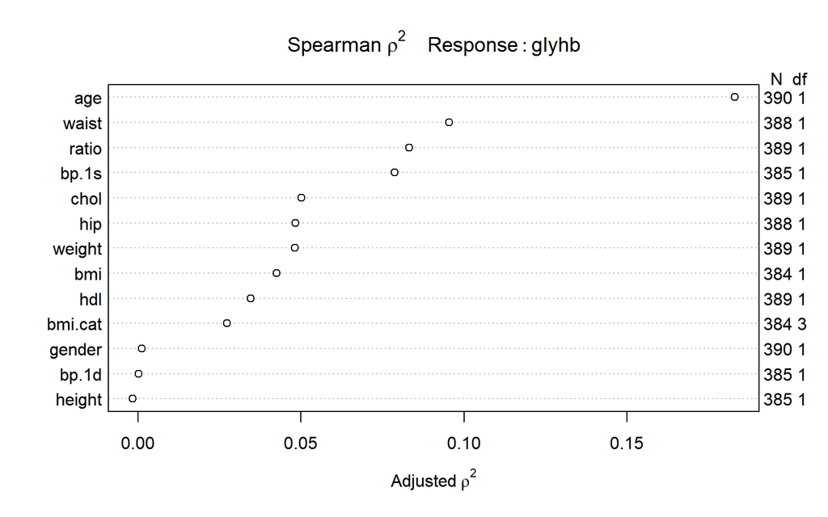

```r
plot(spearman2(glyhb ~ chol + hdl + ratio + age + gender + height + weight + bp.1s + bp.1d + waist + hip + bmi + bmi.cat, data = diabetes))
```

The quantitative outcome `glyhb` will be predicted with some combination of the following nine variables:

- `age`
- `waist`
- `ratio`
- `bp.1s`
- `chol`
- `hip`
- `weight`
- `bmi`
- `hdl`

The Spearman *rho<sup>2</sup>* plot suggests that these nine variables are importnat. The plot does not account for the missing values and this may have some effects.

# 8 Task 8: My Planned Logistic Regression Model

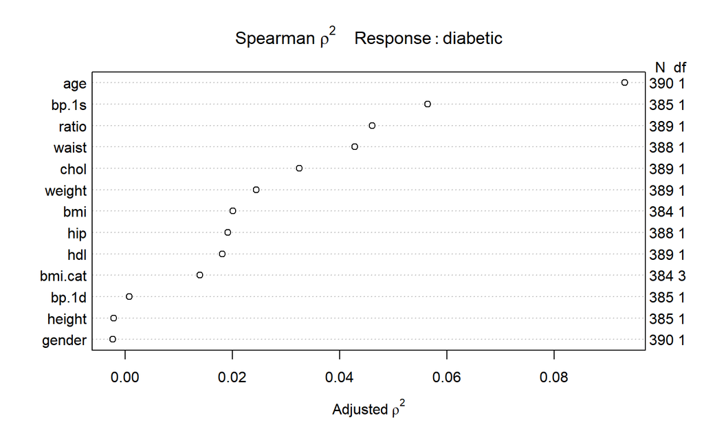

```r
plot(spearman2(diabetic ~ chol + hdl + ratio + age + gender + height + weight + bp.1s + bp.1d + waist + hip + bmi + bmi.cat, data = diabetes))
```

The binary outcome `diabetic` will be predicted with some combination of the following ten variables:

- `age`
- `bp.1s`
- `ratio`
- `waist`
- `chol`
- `weight`
- `bmi`
- `hip`
- `hdl`
- `bmi.cat`

The Spearman *rho<sup>2</sup>* plot suggests that these are important predictors but the plot was made without accounting for the missing values. This may have some effects.

# 9 Task 9: Affirmation

- I am certain that it is completely appropriate for these data to be shared with anyone, without any conditions. There are no concerns about privacy or security.

# 10 Task 10 Analysis: Linear Regression

```r
set.seed(432432)

diabetes2 <- diabetes %>%
  impute_rlm(height + weight ~ age + gender) %>%
  impute_rlm(hip + waist ~ gender + height + weight) %>%
  impute_rlm(bp.1d + bp.1s ~ age + gender) %>%
  impute_rlm(chol + hdl + ratio ~ age + gender + bp.1d + bp.1s) %>%
  impute_rlm(bmi ~ height + weight) %>%
  impute_cart(bmi.cat ~ age + gender) %>%
  impute_cart(diabetic ~ bp.1d + bp.1s) %>%
  impute_rlm(glyhb ~ .)
# rlm(robust linear model) is for quantitative variables and
# cart(decision tree approach) is for categorical variables

diat <- with(diabetes2, cbind(chol, hdl, ratio, age, gender, height, weight,
                              bp.1s, bp.1d, waist, hip, bmi, bmi.cat))
rs.ks <- regsubsets(diat, y = diabetes2$glyhb,
                    nvmax = 13, nbest = 1)
rs.summ <- summary(rs.ks)
rs.summ
```

```
Subset selection object
13 Variables  (and intercept)
        Forced in Forced out
chol        FALSE      FALSE
hdl         FALSE      FALSE
ratio       FALSE      FALSE
age         FALSE      FALSE
gender      FALSE      FALSE
height      FALSE      FALSE
weight      FALSE      FALSE
bp.1s       FALSE      FALSE
bp.1d       FALSE      FALSE
waist       FALSE      FALSE
hip         FALSE      FALSE
bmi         FALSE      FALSE
bmi.cat     FALSE      FALSE
1 subsets of each size up to 13
Selection Algorithm: exhaustive
          chol hdl ratio age gender height weight bp.1s bp.1d waist hip
1  ( 1 )  " "  " " " "   "*" " "    " "    " "    " "   " "   " "   " "
2  ( 1 )  " "  " " "*"   "*" " "    " "    " "    " "   " "   " "   " "
3  ( 1 )  " "  " " "*"   "*" " "    " "    "*"    " "   " "   " "   " "
4  ( 1 )  " "  "*" "*"   "*" " "    " "    "*"    " "   " "   " "   " "
5  ( 1 )  " "  "*" "*"   "*" " "    " "    "*"    " "   " "   " "   " "
6  ( 1 )  " "  "*" "*"   "*" "*"    " "    "*"    " "   " "   " "   " "
7  ( 1 )  " "  "*" "*"   "*" " "    " "    "*"    "*"   "*"   " "   " "
8  ( 1 )  " "  "*" "*"   "*" "*"    " "    "*"    "*"   "*"   " "   " "
9  ( 1 )  " "  "*" "*"   "*" "*"    " "    "*"    "*"   "*"   " "   " "
10  ( 1 ) " "  "*" "*"   "*" "*"    " "    "*"    "*"   "*"   "*"   " "
11  ( 1 ) " "  "*" "*"   "*" "*"    "*"    "*"    "*"   "*"   "*"   " "
12  ( 1 ) "*"  "*" "*"   "*" "*"    "*"    "*"    "*"   "*"   "*"   " "
13  ( 1 ) "*"  "*" "*"   "*" "*"    "*"    "*"    "*"   "*"   "*"   "*"
          bmi bmi.cat
1  ( 1 )  " " " "
2  ( 1 )  " " " "
3  ( 1 )  " " " "
4  ( 1 )  " " " "
5  ( 1 )  " " "*"
6  ( 1 )  " " "*"
7  ( 1 )  " " "*"
8  ( 1 )  " " "*"
9  ( 1 )  "*" "*"
10  ( 1 ) "*" "*"
11  ( 1 ) "*" "*"
12  ( 1 ) "*" "*"
13  ( 1 ) "*" "*"
```

```r
rs.summ$which
```

```
   (Intercept)  chol   hdl ratio  age gender height weight bp.1s bp.1d
1         TRUE FALSE FALSE FALSE TRUE  FALSE  FALSE  FALSE FALSE FALSE
2         TRUE FALSE FALSE  TRUE TRUE  FALSE  FALSE  FALSE FALSE FALSE
3         TRUE FALSE FALSE  TRUE TRUE  FALSE  FALSE   TRUE FALSE FALSE
4         TRUE FALSE  TRUE  TRUE TRUE  FALSE  FALSE   TRUE FALSE FALSE
5         TRUE FALSE  TRUE  TRUE TRUE  FALSE  FALSE   TRUE FALSE FALSE
6         TRUE FALSE  TRUE  TRUE TRUE   TRUE  FALSE   TRUE FALSE FALSE
7         TRUE FALSE  TRUE  TRUE TRUE  FALSE  FALSE   TRUE  TRUE  TRUE
8         TRUE FALSE  TRUE  TRUE TRUE   TRUE  FALSE   TRUE  TRUE  TRUE
9         TRUE FALSE  TRUE  TRUE TRUE   TRUE  FALSE   TRUE  TRUE  TRUE
10        TRUE FALSE  TRUE  TRUE TRUE   TRUE  FALSE   TRUE  TRUE  TRUE
11        TRUE FALSE  TRUE  TRUE TRUE   TRUE   TRUE   TRUE  TRUE  TRUE
12        TRUE  TRUE  TRUE  TRUE TRUE   TRUE   TRUE   TRUE  TRUE  TRUE
13        TRUE  TRUE  TRUE  TRUE TRUE   TRUE   TRUE   TRUE  TRUE  TRUE
   waist   hip   bmi bmi.cat
1  FALSE FALSE FALSE   FALSE
2  FALSE FALSE FALSE   FALSE
3  FALSE FALSE FALSE   FALSE
4  FALSE FALSE FALSE   FALSE
5  FALSE FALSE FALSE    TRUE
6  FALSE FALSE FALSE    TRUE
7  FALSE FALSE FALSE    TRUE
8  FALSE FALSE FALSE    TRUE
9  FALSE FALSE  TRUE    TRUE
10  TRUE FALSE  TRUE    TRUE
11  TRUE FALSE  TRUE    TRUE
12  TRUE FALSE  TRUE    TRUE
13  TRUE  TRUE  TRUE    TRUE
```

```r
#rs.summ$outmat

rs.summ$aic.c <- 403 * log(rs.summ$rss / 403) + 2 * 2:14 +
  (2 * 2:14 * (2:14 + 1) / (403 - 2:14 -1))

preds.1 <- data_frame(
  k = 2:14,
  r2 = rs.summ$rsq,
  adjr2 = rs.summ$adjr2,
  cp = rs.summ$cp,
  aic.c = rs.summ$aic.c,
  bic = rs.summ$bic
)

preds <- cbind(preds.1, rs.summ$which)

preds
```

```
    k        r2     adjr2        cp    aic.c       bic (Intercept)  chol
1   2 0.1119146 0.1096999 42.016787 594.5116 -35.83312        TRUE FALSE
2   3 0.1899549 0.1859047  5.262525 559.4746 -66.90133        TRUE FALSE
3   4 0.2016453 0.1956426  1.457157 555.6566 -66.76078        TRUE FALSE
4   5 0.2051396 0.1971511  1.721911 555.9395 -62.52960        TRUE FALSE
5   6 0.2081614 0.1981886  2.221327 556.4655 -58.06563        TRUE FALSE
6   7 0.2100422 0.1980731  3.287328 557.5785 -53.02506        TRUE FALSE
7   8 0.2125210 0.1985657  4.056359 558.3939 -48.29270        TRUE FALSE
8   9 0.2140400 0.1980815  5.302020 559.7083 -43.07189        TRUE FALSE
9  10 0.2152222 0.1972501  6.714990 561.2049 -37.67954        TRUE FALSE
10 11 0.2159489 0.1959476  8.354069 562.9455 -32.05400        TRUE FALSE
11 12 0.2162427 0.1941933 10.208194 564.9193 -26.20608        TRUE FALSE
12 13 0.2164770 0.1923685 12.091866 566.9346 -20.32761        TRUE  TRUE
13 14 0.2166619 0.1904836 14.000000 568.9862 -14.42383        TRUE  TRUE
     hdl ratio  age gender height weight bp.1s bp.1d waist   hip   bmi
```

[output cut: 27 more lines]

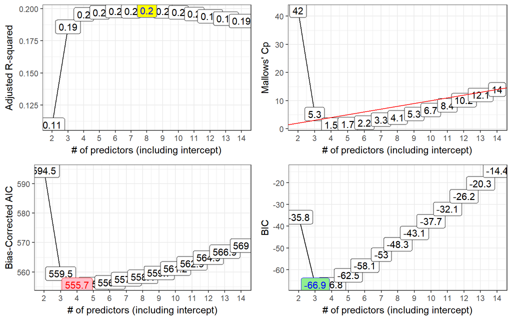

```r
p1 <- ggplot(preds, aes(x = k, y = adjr2,
                            label = round(adjr2,2))) +
    geom_line() +
    geom_label() +
    geom_label(data = subset(preds,
                             adjr2 == max(adjr2)),
               aes(x = k, y = adjr2, label = round(adjr2,2)),
               fill = "yellow", col = "blue") +
    theme_bw() +
    scale_x_continuous(breaks = 2:14) +
    labs(x = "# of predictors (including intercept)",
         y = "Adjusted R-squared")

p2 <- ggplot(preds, aes(x = k, y = cp,
                            label = round(cp,1))) +
    geom_line() +
    geom_label() +
    geom_abline(intercept = 0, slope = 1,
                col = "red") +
    theme_bw() +
    scale_x_continuous(breaks = 2:14) +
    labs(x = "# of predictors (including intercept)",
         y = "Mallows' Cp")

p3 <- ggplot(preds, aes(x = k, y = aic.c,
                             label = round(aic.c,1))) +
    geom_line() +
    geom_label() +
    geom_label(data = subset(preds, aic.c == min(aic.c)),
               aes(x = k, y = aic.c), fill = "pink",
               col = "red") +
    theme_bw() +
    scale_x_continuous(breaks = 2:14) +
    labs(x = "# of predictors (including intercept)",
         y = "Bias-Corrected AIC")

p4 <- ggplot(preds, aes(x = k, y = bic,
                            label = round(bic,1))) +
    geom_line() +
    geom_label() +
    geom_label(data = subset(preds, bic == min(bic)),
               aes(x = k, y = bic),
               fill = "lightgreen", col = "blue") +
    theme_bw() +
    scale_x_continuous(breaks = 2:14) +
    labs(x = "# of predictors (including intercept)",
         y = "BIC")

gridExtra::grid.arrange(p1, p2, p3, p4, nrow = 2)
```

```r
# k = 8, max adjr2
# k = 3, cp near p and far left
# k = 4, min aic.c
# k = 3, min bic

m.int <- lm(glyhb ~ 1, data = diabetes2)
m03 <- lm(glyhb ~ age + ratio, data = diabetes2)
m04 <- lm(glyhb ~ age + ratio + weight, data = diabetes2)
m08 <- lm(glyhb ~ age + ratio + weight + hdl + bmi.cat + bp.1s + bp.1d,
          data = diabetes2)
m.full <- lm(glyhb ~ age + ratio + weight + hdl + bmi.cat + bp.1s + bp.1d +
               gender + bmi + waist + height + chol + hip, data = diabetes2)
anova(m.full, m08, m04, m03, m.int)
```

```
Analysis of Variance Table

Model 1: glyhb ~ age + ratio + weight + hdl + bmi.cat + bp.1s + bp.1d +
    gender + bmi + waist + height + chol + hip
Model 2: glyhb ~ age + ratio + weight + hdl + bmi.cat + bp.1s + bp.1d
Model 3: glyhb ~ age + ratio + weight
Model 4: glyhb ~ age + ratio
Model 5: glyhb ~ 1
  Res.Df    RSS Df Sum of Sq       F  Pr(>F)
1    387 1535.7
2    393 1543.5 -6     -7.88  0.3310 0.92052
3    399 1568.1 -6    -24.57  1.0320 0.40390
4    400 1591.1 -1    -22.96  5.7866 0.01662 *
5    402 1964.2 -2   -373.11 47.0130 < 2e-16 ***
---
Signif. codes:  0 '***' 0.001 '**' 0.01 '*' 0.05 '.' 0.1 ' ' 1
```

```r
# by the signicance tests, m04 is the model I would choose.
# The third p-value is < 0.05, meaning I lose significant predictive value by dropping
# down to m03.

AIC(m03, m04, m08)
```

```
    df      AIC
m03  4 1705.079
m04  5 1701.221
m08 11 1706.856
```

```r
BIC(m03, m04, m08)
```

```
    df      BIC
m03  4 1721.075
m04  5 1721.215
m08 11 1750.844
```

```r
# Smallest AIC is observed with m04 while m03 is preferred with BIC.
# BIC often suggests smaller models

# DO CROSS VALIDATION

d <- datadist(diabetes2)
options(datadist = 'd')

lin.reg <- ols(glyhb ~ rcs(age, 4) + rcs(waist, 3) + rcs(ratio, 3) +
                rcs(bp.1s, 3), data = diabetes2, x = TRUE, y = TRUE)
anova(lin.reg)
```

```
                Analysis of Variance          Response: glyhb

 Factor          d.f. Partial SS   MS          F     P
 age               3  1.501634e+02 50.05445669 13.14 <.0001
  Nonlinear        2  4.475441e+01 22.37720450  5.87 0.0031
 waist             2  2.406998e+01 12.03498954  3.16 0.0435
  Nonlinear        1  2.595485e-02  0.02595485  0.01 0.9343
 ratio             2  1.218526e+02 60.92630036 15.99 <.0001
  Nonlinear        1  1.751216e+01 17.51215575  4.60 0.0326
 bp.1s             2  4.663538e+00  2.33176898  0.61 0.5427
  Nonlinear        1  3.655131e+00  3.65513057  0.96 0.3279
 TOTAL NONLINEAR   5  7.212917e+01 14.42583320  3.79 0.0023
 REGRESSION        9  4.671133e+02 51.90147300 13.62 <.0001
 ERROR           393  1.497084e+03  3.80937369
```

```r
summary(lin.reg)
```

```
             Effects              Response : glyhb

 Factor Low   High  Diff. Effect  S.E.    Lower 0.95 Upper 0.95
 age     34.0  60.0 26.0  1.68950 0.28506  1.129000  2.24990
 waist   33.0  41.0  8.0  0.37808 0.17915  0.025865  0.73030
 ratio    3.2   5.4  2.2  0.41148 0.19463  0.028842  0.79413
 bp.1s  122.0 146.0 24.0  0.15020 0.14864 -0.142030  0.44243
```

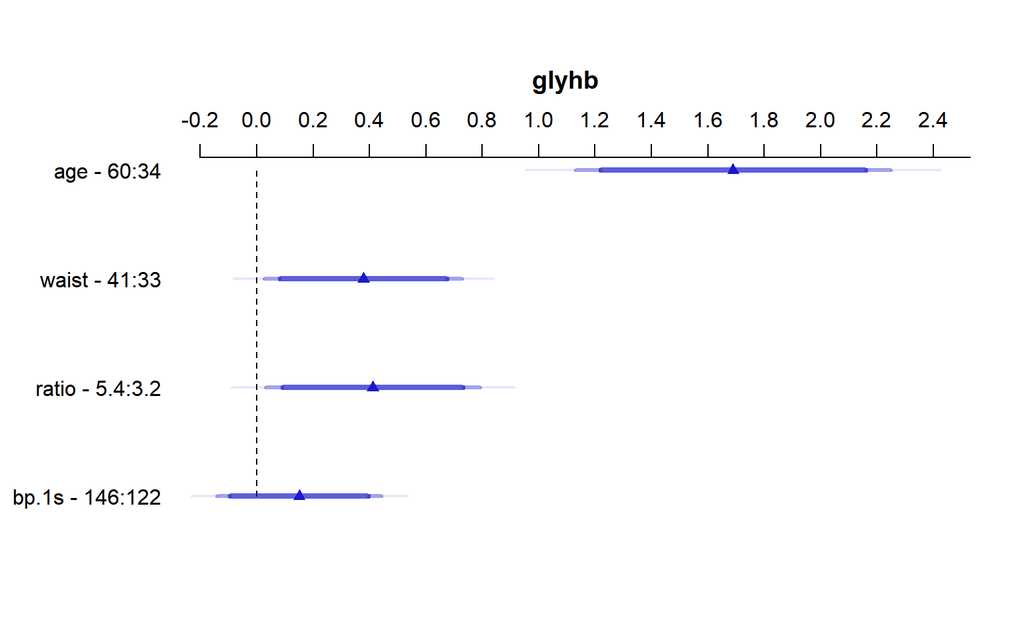

```r
plot(summary(lin.reg))
```